# Session 4 - Introduction to the Tidyverse - Statistics

Jalal Al-Tamimi

Université de Paris

04 February 2022

# 1 Loading packages

```r
## Use the code below to check if you have all required packages installed. If some are not installed already, the code below will install these. If you have all packages installed, then you could load them with the second code.
requiredPackages = c('tidyverse', 'languageR', 'Hmisc', 'corrplot', 'broom', 'knitr', 'xtable', 'ggsignif')
for(p in requiredPackages){
  if(!require(p,character.only = TRUE)) install.packages(p)
  library(p,character.only = TRUE)
}
```

# 2 Inferential statistics

## 2.1 Introduction

What do we mean by inferential statistics? We want to evaluate if there are differences observed between two groups of datapoints and if these differences are statistically significant.

For this, we need to pay attention to the format of our outcome and predictors. An outcome is the response variable (or dependent variable); a predictor is our independent variable(s).

## 2.2 Type of outcomes

It is important to know the class of the outcome before doing any pre-data analyses or inferential statistics. Outcome classes can be one of:

1. `Numeric`: As an example, we have length/width of leaf; height of mountain; fundamental frequency of the voice; etc. These are `true` numbers and we can use summaries, t-tests, linear models, etc. Integer are a family of numeric variables and can still be considered as a normal numeric variable.
2. `Categorical` (Unordered): Observations for two or more categories. As an example, we can have gender of a speaker (male or female); responses to a True vs False perception tests; Colour (unordered) categorisation, e.g., red, blue, yellow, orange, etc.. For these we can use a Generalised Linear Model (binomial or multinomial) or a simple chi-square test. Count data are numbers related to a category. But these should be analysed using a poisson logistic regression
3. `Categorical` (Ordered): When you run a rating experiment, where the outcome is either `numeric` (i.e., 1, 2, 3, 4, 5) or `categories` (i.e., disagree, neutral, agree). The `numeric` option is NOT a true number as for the participant, these are categories. Cumulative Logit models (or Generalised Linear Model with a cumulative function) are used. The mean is meaningless here, and the median is a preferred descriptive statistic.

## 2.3 Correlation tests

### 2.3.1 Basic correlations

Let us start with a basic correlation test. We want to evaluate if two numeric variables are correlated with each other.

We use the function `cor` to obtain the pearson correlation and `cor.test` to run a basic correlation test on our data with significance testing

```r
cor(english$RTlexdec, english$RTnaming, method = "pearson")
```

```
[1] 0.7587033
```

```r
cor.test(english$RTlexdec, english$RTnaming)
```

```
    Pearson's product-moment correlation

data:  english$RTlexdec and english$RTnaming
t = 78.699, df = 4566, p-value < 2.2e-16
alternative hypothesis: true correlation is not equal to 0
95 percent confidence interval:
 0.7461195 0.7707453
sample estimates:
      cor
0.7587033
```

What are the degrees of freedom? These relate to number of total observations - number of comparisons. Here we have 4568 observations in the dataset, and two comparisons, hence 4568 - 2 = 4566.

For the p value, there is a threshold we usually use. This threshold is p = 0.05. This threshold means we have a minimum to consider any difference as significant or not. 0.05 means that we have a probability to find a significant difference that is at 5% or lower. IN our case, the p value is lower that 2.2e-16. How to interpret this number? this tells us to add 15 0s before the 2!! i.e., 0.0000000000000002. This probability is very (very!!) low. So we conclude that there is a statistically significant correlation between the two variables.

The p value is influenced by various factors, number of observations, strength of the difference, mean values, etc.. You should always be careful with interpreting p values taking everything else into account.

### 2.3.2 Using the package `corrplot`

Above, we did a correlation test on two predictors. What if we want to obtain a nice plot of all numeric predictors and add significance levels?

#### 2.3.2.1 Correlation plots

```r
corr <-
  english %>%
  select(where(is.numeric)) %>%
  cor()
print(corr)
```

```
                                    RTlexdec     RTnaming Familiarity
RTlexdec                         1.000000000  0.758703280 -0.44440973
RTnaming                         0.758703280  1.000000000 -0.09479307
Familiarity                     -0.444409734 -0.094793069  1.00000000
WrittenFrequency                -0.434814982 -0.095994313  0.79125559
WrittenSpokenFrequencyRatio      0.039820007  0.036592754 -0.18989881
FamilySize                      -0.349595853 -0.088037010  0.59191973
DerivationalEntropy             -0.161164620 -0.049456670  0.22071588
InflectionalEntropy             -0.088418681 -0.022110376  0.10795420
NumberSimplexSynsets            -0.309008140 -0.071900207  0.51065170
NumberComplexSynsets            -0.328613209 -0.076384846  0.51001913
LengthInLetters                  0.049747275  0.094497065 -0.08215272
Ncount                          -0.065726313 -0.094669618  0.09650461
MeanBigramFrequency              0.002633525  0.048459360  0.02962138
FrequencyInitialDiphone         -0.074452719 -0.057216874  0.12847193
ConspelV                        -0.032867467 -0.025165185  0.07451417
ConspelN                        -0.107538023 -0.034801239  0.21437628
ConphonV                        -0.021747588  0.001175572  0.05408975
ConphonN                        -0.080930543 -0.014364896  0.16180440
ConfriendsV                     -0.025720833 -0.027741071  0.04584224
ConfriendsN                     -0.117532883 -0.044064997  0.20673977
ConffV                          -0.016494945  0.007924551  0.05610343
ConffN                          -0.005679088  0.011407182  0.02945722
ConfbV                          -0.022515482  0.019159417  0.05687343
ConfbN                          -0.018539499  0.017011731  0.05199653
NounFrequency                   -0.167189500 -0.043148572  0.38119070
VerbFrequency                   -0.076388309 -0.024593780  0.23817700
FrequencyInitialDiphoneWord     -0.042640861  0.020488545  0.09106333
FrequencyInitialDiphoneSyllable -0.035503708  0.026897756  0.07354114
CorrectLexdec                   -0.253188184  0.151348043  0.52685458
                                WrittenFrequency
RTlexdec                             -0.43481498
RTnaming                             -0.09599431
Familiarity                           0.79125559
WrittenFrequency                      1.00000000
WrittenSpokenFrequencyRatio           0.07158067
FamilySize                            0.66253864
DerivationalEntropy                   0.25522889
InflectionalEntropy                  -0.04048005
NumberSimplexSynsets                  0.55874958
```

[output cut: 425 more lines]

```
ConspelV                          0.049342737
ConspelN                          0.104328581
ConphonV                          0.020750103
ConphonN                          0.068788492
ConfriendsV                       0.045758455
ConfriendsN                       0.124420710
ConffV                            0.007290473
ConffN                           -0.007205900
ConfbV                            0.005393638
ConfbN                            0.003939158
NounFrequency                     0.128263251
VerbFrequency                     0.050165423
FrequencyInitialDiphoneWord       0.062039751
FrequencyInitialDiphoneSyllable   0.057000795
CorrectLexdec                     1.000000000
```

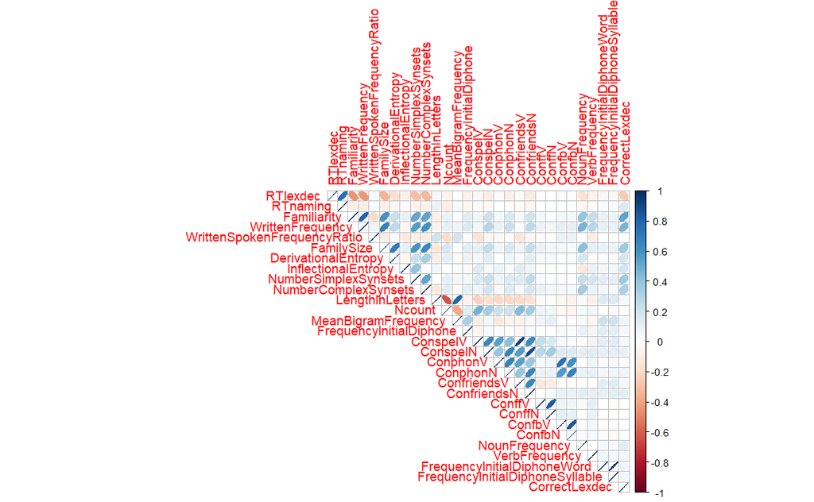

```r
corrplot(corr, method = 'ellipse', type = 'upper')
```

#### 2.3.2.2 More advanced

Let’s first compute the correlations between all numeric variables and plot these with the p values

```r
## correlation using "corrplot"
## based on the function `rcorr' from the `Hmisc` package
## Need to change dataframe into a matrix
corr <-
  english %>%
  select(where(is.numeric)) %>%
  as.matrix(english) %>%
  rcorr(type = "pearson")
print(corr)
```

```
                                RTlexdec RTnaming Familiarity
RTlexdec                            1.00     0.76       -0.44
RTnaming                            0.76     1.00       -0.09
Familiarity                        -0.44    -0.09        1.00
WrittenFrequency                   -0.43    -0.10        0.79
WrittenSpokenFrequencyRatio         0.04     0.04       -0.19
FamilySize                         -0.35    -0.09        0.59
DerivationalEntropy                -0.16    -0.05        0.22
InflectionalEntropy                -0.09    -0.02        0.11
NumberSimplexSynsets               -0.31    -0.07        0.51
NumberComplexSynsets               -0.33    -0.08        0.51
LengthInLetters                     0.05     0.09       -0.08
Ncount                             -0.07    -0.09        0.10
MeanBigramFrequency                 0.00     0.05        0.03
FrequencyInitialDiphone            -0.07    -0.06        0.13
ConspelV                           -0.03    -0.03        0.07
ConspelN                           -0.11    -0.03        0.21
ConphonV                           -0.02     0.00        0.05
ConphonN                           -0.08    -0.01        0.16
ConfriendsV                        -0.03    -0.03        0.05
ConfriendsN                        -0.12    -0.04        0.21
ConffV                             -0.02     0.01        0.06
ConffN                             -0.01     0.01        0.03
ConfbV                             -0.02     0.02        0.06
ConfbN                             -0.02     0.02        0.05
NounFrequency                      -0.17    -0.04        0.38
VerbFrequency                      -0.08    -0.02        0.24
FrequencyInitialDiphoneWord        -0.04     0.02        0.09
FrequencyInitialDiphoneSyllable    -0.04     0.03        0.07
CorrectLexdec                      -0.25     0.15        0.53
                                WrittenFrequency
RTlexdec                                   -0.43
RTnaming                                   -0.10
Familiarity                                 0.79
WrittenFrequency                            1.00
WrittenSpokenFrequencyRatio                 0.07
FamilySize                                  0.66
DerivationalEntropy                         0.26
InflectionalEntropy                        -0.04
NumberSimplexSynsets                        0.56
```

[output cut: 790 more lines]

```
ConspelV                        0.0008
ConspelN                        0.0000
ConphonV                        0.1609
ConphonN                        0.0000
ConfriendsV                     0.0020
ConfriendsN                     0.0000
ConffV                          0.6223
ConffN                          0.6263
ConfbV                          0.7155
ConfbN                          0.7901
NounFrequency                   0.0000
VerbFrequency                   0.0007
FrequencyInitialDiphoneWord     0.0000
FrequencyInitialDiphoneSyllable 0.0001
CorrectLexdec
```

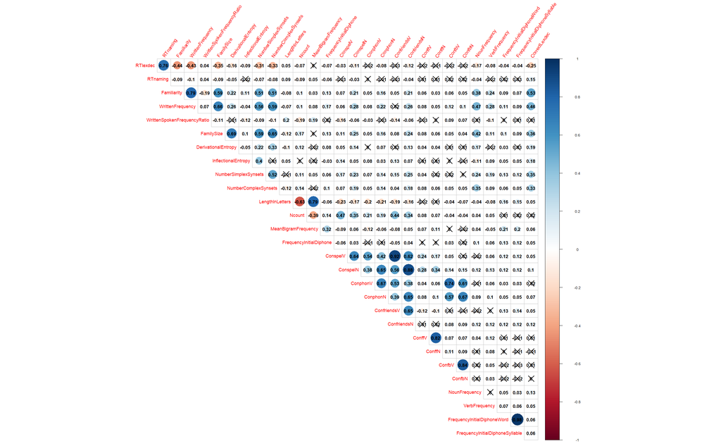

```r
# use corrplot to obtain a nice correlation plot!
corrplot(corr$r, p.mat = corr$P,
         addCoef.col = "black", diag = FALSE, type = "upper", tl.srt = 55)
```